# HW01_Solution

**Deep Learning for Mechanical Engineering**  
**Homework 01: Solution**  
**Due Tuesday, 04/02/2019, 3:30 PM**

By Prof. Seungchul Lee  
http://iai.postech.ac.kr/  
Industrial AI Lab at POSTECH

- For your handwritten solution, hand in your hardcopy before the class begins.
- For your code, email your .ipynb file to iai.postech@gmail.com. Only .ipynb file will be graded.
- When you send an e-mail, you **must write down [Deep Learning Homework] on the title**.
- And please write your NAME on your .ipynb files. ex) 김승욱_20192319 _HW1.ipynb
- Do not submit a printed version of your code. It will not be graded.
- If you have any questions on the homework problems, please email our TA via iai.postech@gmail.com.

# Problem 1: Optimization and Gradiet Descent

(a) Find the solution using the derivatives of the following objective function by hands:

$$\min_{x_1, \,x_2} \, (2x_1 - 1)^2 + (-x_1 + x_2)^2 + (2x_2 +1)^2$$

(b) Formulate the above as a least-squares problem (*i.e.*, find one of possible $A$ and $b$), and solve it using TensorFlow.

$$\min_{x} \, \lVert Ax - b\rVert_2 ^2$$

(c) How many suboptimal points exist? Why?

### Solution

```python
import numpy as np
import matplotlib.pyplot as plt
import tensorflow as tf

A = np.array([[2, 0], [-1, 1], [0, 2]])
b = np.array([[1], [0], [-1]])

A_p = tf.placeholder(tf.float32, [3, 2])
b_p = tf.placeholder(tf.float32, [3, 1])
x = tf.Variable(tf.random.normal([2,1], stddev = 0.1))
```

```python
output = tf.matmul(A_p,x)

loss = tf.norm(tf.subtract(output, b_p), 2)

LR = 0.01
optm = tf.train.AdamOptimizer(LR).minimize(loss)

init = tf.global_variables_initializer()
```

```python
sess = tf.Session()
sess.run(init)
```

```python
for _ in range(100):
    sess.run(optm, feed_dict = {A_p: A, b_p: b})
```

```python
sess.run(x)
```

```
array([[ 0.334218  ],
       [-0.33313596]], dtype=float32)
```

# Problem 2: Feature Extraction

In this problem, we will try to classify handwritten digits. We simplify this digit classification problem into a binary classification between digit 0 and digit 1.

You can download data from

- [digit 0](https://www.dropbox.com/s/41bpk4to767g2ri/mnist_digit_0.pkl?dl=1)
- [digit 1](https://www.dropbox.com/s/jmzd5yny6epqzj9/mnist_digit_1.pkl?dl=1)

### Step 1. Load and check data files

| Data | Data dexcription |
| --- | --- |
| 0 | 500 images (28×28 pixels) of handwritten digit 0 |
| 1 | 500 images (28×28 pixels) of handwritten digit 1 |

```python
from six.moves import cPickle

digit0 = cPickle.load(open('data_files/mnist_digit_0.pkl', 'rb'))
digit1 = cPickle.load(open('data_files/mnist_digit_1.pkl', 'rb'))
```

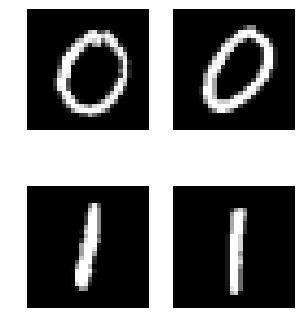

```python
plt.figure(figsize=(10, 6))
plt.subplot(2,4,1), plt.imshow(digit0[np.random.randint(0, 200)], 'gray'), plt.axis('off')
plt.subplot(2,4,2), plt.imshow(digit0[np.random.randint(0, 200)], 'gray'), plt.axis('off')
plt.subplot(2,4,5), plt.imshow(digit1[np.random.randint(0, 200)], 'gray'), plt.axis('off')
plt.subplot(2,4,6), plt.imshow(digit1[np.random.randint(0, 200)], 'gray'), plt.axis('off')
plt.show()
```

(1) Here, we have handwritten data digit 0 and digit 1. Display random images of digit 0 and digit 1, respectively.

(Hint : You can use matplotlib.pyplot library)

### Step 2. Extract feature

Now we must select the own ‘features’ from image data to detect digit 0 and digit 1. Two features are recommended

- The total average pixels located at the center of the image (`img[10:20,10:20]`).
- The total average pixels over the entire location.
- Include the ones as our bias term.

$$\Phi(x) = \begin{bmatrix} 1 \\ \text{feature 1}\\ \text{feature 2} \end{bmatrix}$$

(2) You should end up with a $1000\times3$ input matrix with the first $500$ rows correspond to all of the `data0` and the second 500 rows correspond to the two features for all of the given `data1`. This matrix is matrix $\Phi$ which we learned in a class.

```python
# Average pixels locaed at the center of the image
feature0_1 = np.mean(digit0[:, 10:20, 10:20], axis = (1, 2)).reshape(-1, 1)
feature1_1 = np.mean(digit1[:, 10:20, 10:20], axis = (1, 2)).reshape(-1, 1)

# Total average pixels over the entire location
feature0_2 = np.mean(digit0, axis = (1, 2)).reshape(-1, 1)
feature1_2 = np.mean(digit1, axis = (1, 2)).reshape(-1, 1)

Theta0 = np.hstack([np.ones([feature0_1.shape[0], 1]), feature0_1, feature0_2])
Theta1 = np.hstack([np.ones([feature0_1.shape[0],1]), feature1_1, feature1_2])
Theta = np.vstack([Theta0, Theta1])

print(Theta.shape)
```

```
(1000, 3)
```

### Step 3. Plot the data

(3) Plot the data to see if classes are linearly separable. The expected plot is following:

[figure not shown]

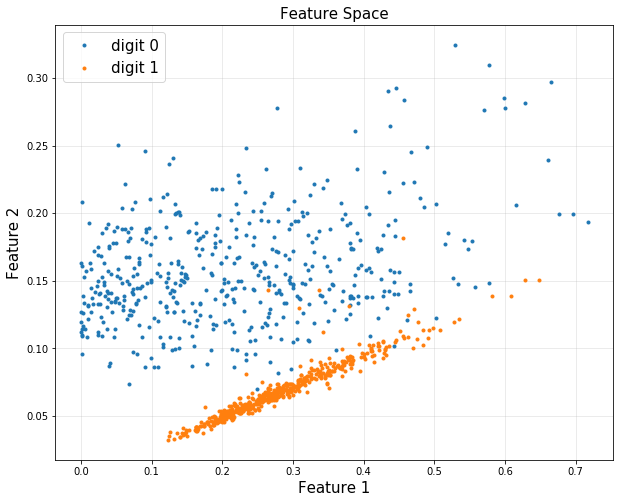

```python
plt.figure(figsize = (10, 8))
plt.title('Feature Space', fontsize = 15)
plt.plot(feature0_1, feature0_2, '.', label = 'digit 0')
plt.plot(feature1_1, feature1_2, '.', label = 'digit 1')
plt.grid(alpha = 0.3)
plt.legend(fontsize = 15)
plt.xlabel('Feature 1', fontsize = 15)
plt.ylabel('Feature 2', fontsize = 15)
plt.show()
```

# Problem 3: ANN Regression

In this problem, you are asked to use TensorFlow to implement the linear regression algorithm. By doing this, we hope that you are getting familiar with the syntax of TensorFlow.

```python
import numpy as np
import matplotlib.pyplot as plt
import tensorflow as tf
```

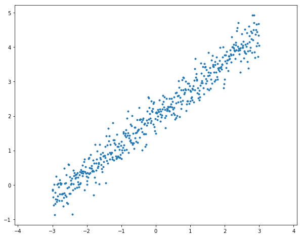

```python
# Data Generation

m =  500

data_x = np.linspace(-3, 3, m)
data_y = 0.8*data_x + 2 + np.random.randn(m)*0.3

plt.figure(figsize = (10,8))
plt.plot(data_x, data_y, '.')
plt.axis('equal')
plt.show()
```

We will build the simplest ANN model as shown in the following figure in order to find the best line fit (i.e., linear regression) for the given training data set. Note that there is no hidden layer, and both the input and output layer have only one neuron.

[figure not shown]

Fill out the blank in the following cells.

### Solution

```python
# the sizes of input and output

n_input = 1
n_output = 1
```

```python
# define decision variables in tf

weights = {
    'w' : tf.Variable(tf.random_normal([n_input, n_output], stddev = 0.1))
}

biases = {
    'b' : tf.Variable(tf.random_normal([n_output], stddev = 0.1))
}
```

```python
# define placeholders

x = tf.placeholder(tf.float32, [None, n_input])
y = tf.placeholder(tf.float32, [None, n_output])
```

```python
# define model

def model(x, weights, biases):
    output = tf.add(tf.matmul(x, weights['w']), biases['b'])
    return output
```

```python
# define loss

pred = model(x, weights, biases)
loss = tf.square(tf.subtract(y, pred))
loss = tf.reduce_mean(loss)
```

```python
# define an optimizer

LR = 0.01
# optm = tf.train.AdamOptimizer(LR).minimize(loss)
optm = tf.train.GradientDescentOptimizer(LR).minimize(loss)
```

```python
# tf.Variable initializer

sess = tf.Session()
sess.run(tf.global_variables_initializer())
```

```python
# define parameters

n_batch = 10
n_iter = 2500
n_prt = 250
```

```python
# we provide 'next_batch function' for your convenience

def next_batch(x, y, n_batch):
    m = x.shape[0]
    idx = np.random.randint(0, m, n_batch)
    x_train, y_train = x[idx].reshape(-1,1), y[idx].reshape(-1,1)
    return x_train, y_train
```

```python
# optimizing

for epoch in range(n_iter):
    train_x, train_y = next_batch(data_x, data_y, n_batch)
    sess.run(optm, feed_dict = {x: train_x, y: train_y})

    if epoch % n_prt == 0:
        c = sess.run(loss, feed_dict = {x: train_x, y: train_y})
        print ("Iter : {}".format(epoch))
        print ("Cost : {}".format(c))
```

```
Iter : 0
Cost : 7.174134731292725
Iter : 250
Cost : 0.1445387303829193
Iter : 500
Cost : 0.11062383651733398
Iter : 750
Cost : 0.12720851600170135
Iter : 1000
Cost : 0.07027532905340195
Iter : 1250
Cost : 0.09510992467403412
Iter : 1500
Cost : 0.09490144997835159
Iter : 1750
Cost : 0.061674416065216064
Iter : 2000
Cost : 0.13439270853996277
Iter : 2250
Cost : 0.06453926861286163
```

```python
w = sess.run(weights['w'])
b = sess.run(biases['b'])

w_hat = w[0,0]
b_hat = b[0]

print ("w_hat : {}".format(w_hat))
print ("b_hat : {}".format(b_hat))
```

```
w_hat : 0.7994176149368286
b_hat : 1.9942840337753296
```

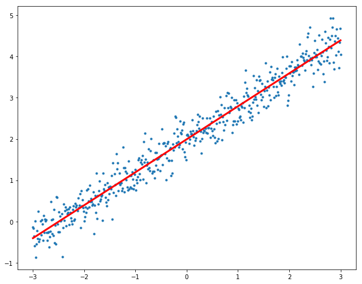

```python
# plot

learned_y = data_x*w_hat + b_hat

plt.figure(figsize = (10,8))
plt.plot(data_x, data_y, '.')
plt.plot(data_x, learned_y, 'r', linewidth = 3)
plt.show()
```

# Problem 4: Autoencoder

In this problem, we would like to explore on how to decide the dimension of latent space in an autoenocoder. Let's use the MNIST data set and the autoencoder structure that we used in class.

- change the number of latent variables from 1 to 20 and
- compute the loss fuction for each case to see how well the autoencoder reconstructs the input
- You are expected to plot the graph similar to the below one.

Then state your justification for the number of latent variable on your own words. (note that there is no right answer for the specific number of latent variable in this problem)

Hint: the basic idea or approach is similar to that of K-means (https://en.wikipedia.org/wiki/Elbow_method_(clustering)).

[figure not shown]

### Solution

```python
import numpy as np
import matplotlib.pyplot as plt
import tensorflow as tf

def batch_maker(batch_size, img, label):
    img_len = len(img)
    random_idx = np.random.randint(img_len, size = batch_size)
    return img[random_idx], label[random_idx]

from tensorflow.examples.tutorials.mnist import input_data
mnist = input_data.read_data_sets("MNIST_data/", one_hot=True)

train_idx = ((np.argmax(mnist.train.labels, 1) == 1) | \
             (np.argmax(mnist.train.labels, 1) == 5) | \
             (np.argmax(mnist.train.labels, 1) == 6))
test_idx = ((np.argmax(mnist.test.labels, 1) == 1) | \
            (np.argmax(mnist.test.labels, 1) == 5) | \
            (np.argmax(mnist.test.labels, 1) == 6))

train_imgs   = mnist.train.images[train_idx]
train_labels = mnist.train.labels[train_idx]
test_imgs    = mnist.test.images[test_idx]
test_labels  = mnist.test.labels[test_idx]
n_train      = train_imgs.shape[0]
n_test       = test_imgs.shape[0]

loss_latent = np.zeros((20,1))

for i in range(20):
    n_input = 28*28

    n_encoder1 = 500
    n_encoder2 = 300

    n_latent = i + 1

    n_decoder1 = 300
    n_decoder2 = 500

    weights = {
        'encoder1' : tf.Variable(tf.random_normal([n_input, n_encoder1], stddev = 0.1)),
        'encoder2' : tf.Variable(tf.random_normal([n_encoder1, n_encoder2], stddev = 0.1)),
        'latent' : tf.Variable(tf.random_normal([n_encoder2, n_latent], stddev = 0.1)),
        'decoder1' : tf.Variable(tf.random_normal([n_latent, n_decoder1], stddev = 0.1)),
        'decoder2' : tf.Variable(tf.random_normal([n_decoder1, n_decoder2], stddev = 0.1)),
        'reconst' : tf.Variable(tf.random_normal([n_decoder2, n_input], stddev = 0.1))
    }

    biases = {
        'encoder1' : tf.Variable(tf.random_normal([n_encoder1], stddev = 0.1)),
        'encoder2' : tf.Variable(tf.random_normal([n_encoder2], stddev = 0.1)),
        'latent' : tf.Variable(tf.random_normal([n_latent], stddev = 0.1)),
        'decoder1' : tf.Variable(tf.random_normal([n_decoder1], stddev = 0.1)),
        'decoder2' : tf.Variable(tf.random_normal([n_decoder2], stddev = 0.1)),
        'reconst' : tf.Variable(tf.random_normal([n_input], stddev = 0.1))
    }

    x = tf.placeholder(tf.float32, [None, n_input])

    def encoder(x, weights, biases):
        encoder1 = tf.add(tf.matmul(x, weights['encoder1']), biases['encoder1'])
        encoder1 = tf.nn.tanh(encoder1)

        encoder2 = tf.add(tf.matmul(encoder1, weights['encoder2']), biases['encoder2'])
        encoder2 = tf.nn.tanh(encoder2)

        latent = tf.add(tf.matmul(encoder2, weights['latent']), biases['latent'])

        return latent


    def  decoder(latent, weights, biases):
        decoder1 = tf.add(tf.matmul(latent, weights['decoder1']), biases['decoder1'])
        decoder1 = tf.nn.tanh(decoder1)

        decoder2 = tf.add(tf.matmul(decoder1, weights['decoder2']), biases['decoder2'])
        decoder2 = tf.nn.tanh(decoder2)

        reconst = tf.add(tf.matmul(decoder2, weights['reconst']), biases['reconst'])

        return reconst

    LR = 0.0001

    latent = encoder(x, weights, biases)
    reconst = decoder(latent, weights, biases)
    loss = tf.square(tf.subtract(x, reconst))
    loss = tf.reduce_mean(loss)

    optm = tf.train.AdamOptimizer(LR).minimize(loss)

    n_batch = 50
    n_iter = 2500
    n_prt = 250

    sess = tf.Session()
    sess.run(tf.global_variables_initializer())

    for epoch in range(n_iter):
        train_x, train_y = batch_maker(n_batch, train_imgs, train_labels)
        sess.run(optm, feed_dict = {x : train_x})

        if epoch % n_prt == 0:
            c = sess.run(loss, feed_dict = {x: train_x})

    loss_latent[i,0] = sess.run(loss, feed_dict = {x: train_x})
    print("Number of latent: {}".format(i+1))
    print("Cost: {}".format(loss_latent[i,0]))
```

[output not shown]

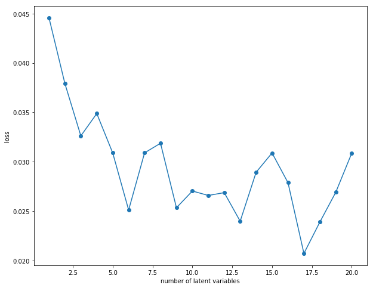

```python
plt.figure(figsize = (10,8))
plt.plot(np.arange(1,21), loss_latent[:,0], 'o-')
plt.xlabel("number of latent variables")
plt.ylabel("loss")
plt.show()
```